# **Introduction to Quarto**

STA 418/518 - Statistical Computing and Graphics with R

Andrew DiLernia

Complete the following activity using Quarto and then submit your .qmd file and output document via Blackboard.

## **Learning Objectives**

- Render Quarto to different formats
- Understand fundamental Markdown syntax
- Use code chunks in Quarto
- Customize code chunk options
- Include plots & tables in Quarto

➡️ First, create a new Quarto document with *File > New File > Quarto Document… > Create*

➡️ Render it by clicking the Render button (top left), choosing to save the file as something without spaces like quarto-activity.

- Also render the document by using the appropriate keyboard shortcut (**Mac**: *Command + Shift + K*, **Windows**: *Ctrl + Shift + K*).

- How does the output differ?
- Looking at the YAML at the top of the document, how does the input differ?

**Note**: We will not use PDF output for this course. If rendering to PDF is something you want to do for another project, you may need to install LaTeX if rendering to PDF causes an error. This can be done by installing the tinytex package by submitting install.packages(“tinytex”) to the Console by pressing return / enter, and then submitting tinytex::install_tinytex() to the Console after the package has been successfully installed.

For the rest of the activity, we will focus on the document that is rendering to an HTML format.

## **Markdown**

Markdown is a lightweight set of conventions for formatting plain text files. It is designed to be easy to read and write, so it is not very customizable but can be learned quickly.

### **Headings**

Headings and subheadings can be included in a file to organize the document.

- # 1st Level Header
- ## 2nd Level Header
- ### 3rd Level Header

➡️ Include a first-level header, second-level header, and third-level header in your document naming them Section 1, Subsection 1.1, and Subsubsection 1.1.1, respectively.

### **Links and Images**

Hyperlinks and external images / GIFs can be included in Quarto documents as well.

➡️ Include a hyperlink linking to the Google homepage.

### **Text Formatting**

Basic formatting of text, such as italicizing, bolding, superscripts, and subscripts can be implemented as well.

| Raw text input | Rendered output |
| --- | --- |
| *italic* | *italic* |
| **bold** | **bold** |
| `code` | code |
| superscript<sup>2</sup> | superscript2 |
| subscript~2~ | subscript2 |

#### *You try*

➡️ Include an italicized word or phrase.

➡️ Include a bold word or phrase.

➡️ Include a word styled showing it is code.

➡️ Include a superscript and a subscript.

## **Code Chunks**

The real power of Quarto comes from the ability to add **code chunks** to the file, which allows us to run R code inside our document:

*# Sophisticated calculation*  
sqrt(49)

There are several ways to insert a code chunk:

1. The keyboard shortcut Cmd/Ctrl + Alt + I (recommended)
2. The “Insert” button icon in the editor toolbar (top right).
3. By manually typing the chunk delimiters ```{r} and ```.

➡️ Add a new code chunk at the bottom of the Quarto document, naming the chunk uptown-chunk by including **#| label: uptown-chunk** as the first line inside the code chunk.

➡️ In the code chunk, use the include_graphics() function from the knitr package to include the image at the following URL: https://github.com/dilernia/STA418-518/blob/main/uptownFunk2.png?raw=true. Note that the URL should be enclosed in quotes when calling the include_graphics() function.

Code chunks have multiple **options** which control how they behave. Some more commonly used code chunk options are below:

*Table 1: Commonly used code chunk options* Option Description eval Determines if the code should be evaluated (true / false) echo Controls whether the code is shown in the output (true / false) include Specifies if the result should be included in the output (true / false) warning Indicates if warnings should be shown (true / false) message Indicates if messages should be shown (true / false) error Include errors in the output. When set to true, runtime errors will not halt processing of the document. (true / false) out-width Width of the plot in the output document out-height Height of the plot in the output document fig-align Figure horizontal alignment (default, left, right, or center)

➡️ Modify uptown-chunk by setting the echo chunk option to be false by including **#| echo: false** immediately below the line with **#| label: uptown-chunk**.

Specify and toggle the include and eval chunk options for the uptown-chunk code chunk and see what happens. Note that some of the code chunk options for controlling the dimensions of figures only apply for graphics produced in code chunks, but not externally included images.

To explore more code chunk options and details, see https://quarto.org/docs/reference/cells/cells-knitr.html?form=MG0AV3.

We can specify default code chunks options for the entire document by customizing the YAML (at the top of the Quarto document) as below.

-–  
title: “Document title”  
author: “Author name”  
date: today  
format:  
html:  
self-contained: true  
embed-resources: true  
execute:  
eval: true # Evaluate code  
echo: true # Show code  
warning: false # Suppress warnings  
message: false # Suppress messages  
-–

### **Including Plots**

Using R code inside chunks that produce plots allows graphics to be directly included in the output document.

For example, let’s explore a data set on storms ⛈️ between 1975 and 2021 from the National Oceanic and Atmospheric Administration (NOAA). In particular, let’s visualize the relationship between the pressure (in millibars) of a storm and its maximum sustained wind speed (in knots).

library(tidyverse)

*# Load storms data set*  
data(storms)

storms |> ggplot(aes(x = pressure, y = wind)) +  
geom_point()

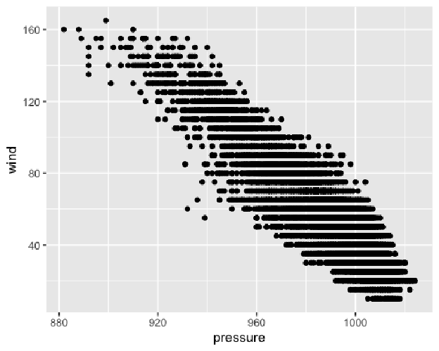

**Note**: If this code has an error such as *Error in library(tidyverse) : there is no package called ‘tidyverse’*, you may need to submit install.packages(‘tidyverse’) to the Console first to install the package. If you do not encounter an error, then it is best not to reinstall the package.

In general, you may need to install an R package by submitting install.packages(“package_name”) to the Console first, replacing “package_name” with the name of the R package to install in quotes. Typically, you only install R packages as you need them.

➡️ Include the code to create a scatter plot above in a new chunk at the bottom of the Quarto document.

➡️ After reviewing their possible values here https://quarto.org/docs/reference/cells/cells-knitr.html?form=MG0AV3#figures, toggle the out-height, out-width, and fig-align chunk options, exploring their effect on the output document.

The code chunk options fig-width and fig-height can also be used to control the dimensions of figures, but these options operate in a different manner than out-width and out-height which rescale the output figures.

### **Inline Code**

Quarto also allows you to use R code outside of code chunks for dynamic text:

xbar <- 2  
se <- 1.3

The following Markdown syntax:

The 95% confidence interval for the mean is (`r xbar - 1.96*se`, `r xbar + 1.96*se`)

produces:

The 95% confidence interval for the mean is (-0.548, 4.548).

➡️ Include a chunk of R code and after that in-line R code at the bottom of the document to reproduce the sentence containing the confidence interval results above.

### **Tables**

Quarto allows you to display nicely formatted tables. Let’s explore a few of the most common R functions for nicely displaying tables in Quarto. To do so, let’s continue with the storms data set looking at the four largest sustained wind speeds recorded for different storms 💨.

*# Largest sustained wind speeds recorded*  
storms_summary <- storms |>  
group_by(name, year) |>  
summarize(max_wind_knots = max(wind)) |>  
ungroup() |>  
slice_max(max_wind_knots, n = 4)

#### *kable() from the knitr package*

library(knitr)

storms_summary |>  
kable()

| *Table 2: Storm summary statistics with kable()* name year max_wind_knots Allen 1980 165 Dorian 2019 160 Gilbert 1988 160 Wilma 2005 160 |
| --- |

The kable() function is the most basic function for including tables in Quarto documents, with relatively stable but limited customization options. This function displays tables for all output formats including PDF, HTML, and Word.

There are multiple ways to customize table captions. A versatile approach is to customize the label and tbl-cap code chunk options as below.

#| label: ‘tbl-a_table_name’

#| tbl-cap: ‘A custom table caption’

Note that the label option must begin with “tbl” prefix to properly include the table caption. For more details regarding customization of included tables, see https://quarto.org/docs/authoring/tables.html.

#### *flextable() from the flextable package*

library(flextable)

storms_summary |>  
flextable() |>  
colformat_double(big.mark = ““, digits = 0) |>  
autofit()

| *Table 3: Storm summary statistics with flextable()* name year max_wind_knots Allen 1980 165 Dorian 2019 160 Gilbert 1988 160 Wilma 2005 160 |
| --- |

The flextable package displays tables for all output formats in a more consistent manner, with a large number of methods for customization that work for all output formats.

#### *gt() from the gt package*

library(gt)

storms_summary |>  
gt()

| *Table 4: Storm summary statistics with gt()* name year max_wind_knots Allen 1980 165 Dorian 2019 160 Gilbert 1988 160 Wilma 2005 160 |
| --- |

The gt package has a wide range of formatting options, including conditional formatting and group-wise summary statistics. It is most easily used with HTML as the output format for Quarto, but not as easily for PDF or Word output when further customizing the table.

#### *Table themes*

There are [many options](https://bookdown.org/yihui/rmarkdown-cookbook/table-other.html) for finely customizing aspects about tables displayed in Quarto. We can also apply complete themes to customize the appearance of tables with minimal code. The flextable package comes with preset themes available.

*# Displaying flextable with tron theme*  
storms_summary |>  
flextable() |>  
autofit() |>  
theme_tron()

| name | year | max_wind_knots |
| --- | --- | --- |
| Allen | 1,980 | 165 |
| Dorian | 2,019 | 160 |
| Gilbert | 1,988 | 160 |
| Wilma | 2,005 | 160 |

For gt tables one must load the gtExtras package to use complete themes. Unfortunately gtExtras does not fully customize the tables when rendering to Word or PDF.

library(gtExtras)

*# Displaying gt with NY Times theme*  
storms_summary |>  
gt() |>  
gt_theme_nytimes()

| name | year | max_wind_knots |
| --- | --- | --- |
| Allen | 1980 | 165 |
| Dorian | 2019 | 160 |
| Gilbert | 1988 | 160 |
| Wilma | 2005 | 160 |

#### *You try*

➡️ Display the storms_summary table applying a complete theme different than the one used above using the gt() function and the [gtExtras](https://jthomasmock.github.io/gtExtras/reference/index.html) R package by viewing the available themes here: https://jthomasmock.github.io/gtExtras/reference/index.html

➡️ Display the storms_summary table applying a complete theme different than the one used above using the flextable() function by viewing the available themes here: https://davidgohel.github.io/flextable/reference/index.html#flextable-themes.

Note that there is a way to apply complete themes for tables displayed with kable() using the [kableExtra](https://cran.r-project.org/web/packages/kableExtra/vignettes/awesome_table_in_html.html) package, but this only works when rendering to HTML format.

### **Word Templates**

- Organizations, such as the [US Department of Agriculture](https://www.nass.usda.gov/Statistics_by_State/Michigan/Publications/Crop_Progress_&_Condition/2019/cw1819mi.pdf), can have weekly or monthly reports that change as data / other inputs are updated.
- When rendering to Word, Quarto can use [Word document templates](https://quarto.org/docs/output-formats/ms-word-templates.html) for consistent formatting, headers, etc. while updating charts & tables.

### **Much More!**

- This activity was made using Quarto.
- This [Quarto Cheat Sheet](https://rstudio.github.io/cheatsheets/quarto.pdf) describes additional features and fundamentals of Quarto.
- [HTML Theming](https://quarto.org/docs/output-formats/html-themes.html) is available when rendering to HTML with Quarto to customize the overall appearance of the output document

### **Bonus (Optional)**

➡️ Toggle the Source and Visual editor buttons in the top left of the editor pane, , to explore the difference between the two modalities in Quarto.

The syntax for Quarto is very similar to that of R Markdown, but the main differences are that Quarto has a simplified YAML, chunk options are specified slightly differently, and Quarto has more of a multilingual focus than R Markdown.